# Deep Learning Model Report

**Multiclass Classification Model**

# Executive Summary / Key Results

## Key Results

**Project:** Multiclass News Classification using Deep Learning

**Dataset:** AG News Dataset  
**Classes:** World, Sports, Business, Sci/Tech  
**Task:** Four-class text classification

**Model:** Feed-forward neural network  
**Final architecture:** 128 → 64 → 4  
**Activations:** ReLU → ReLU → Softmax  
**Optimizer:** RMSprop  
**Loss function:** Categorical Crossentropy  
**Epochs:** 3

**Final Results**

- Test accuracy: **90.20%**
- Overall correct predictions: **6,855 / 7,600**
- Baseline accuracy for four balanced classes: **25%**
- Improvement over baseline: approximately **+65 percentage points**

**Learning Outcomes**

- Text preprocessing and vectorization are essential for neural network text classification.
- More model complexity does not always improve generalization.
- Validation strategy affects both model confidence and computational cost.

# Introduction and Background Information

## Introduction

The purpose of this project is to demonstrate an understanding of Deep Learning concepts through the implementation and evaluation of a neural network classification model. The report will explain these concepts through research into the model components and its implementation on a data set.

## Aims and Objectives

The aim of this project is to explain the implementation and functionality of a Deep Learning Model. The objectives are the following:

1. Present a research about the data provenance
2. Describe the deep learning model definitions, applications and principles.
3. Implement a Deep Learning model by following “the universal workflow of Machine Learning” [Chollet 4.5]
4. Describe the model by evaluating the preparation and functionality.
5. Conclude by analyzing the process of the project

## Data

### Data Provenance

The dataset used in this project comes from the TensorFlow Datasets libraries. “TensorFlow Datasets is a collection of datasets ready to use, with TensorFlow or other Python ML frameworks, such as Jax” (“TensorFlow Datasets: a collection of ready-to-use datasets.”). These datasets provide easy handling when creating complex models.

### AG’s News Subset Dataset

The dataset chosen for the purpose of this project is “ag_news_subset”(AG’s Dataset). These dataset can be found in the TensorFlow list of datasets. Ag’s Dataset “is a collection of more than 1 million news articles” [“ag_news_subset”]. It was gathered by ComeToMyHand, an “academic news search engine” [“ag_news_subset”]. This dataset can be used for non-commercial use as stipulated in the documentation. AG’s dataset contains four classes of “30,000 training samples and 1,900 testing samples with a total of 120,000 and testing 7,600” [“ag_news_subset”].

## Deep Learning Model

### Definition

Machine Learning (ML) is a subset of AI where the functionalities are more specific, for example predict patterns in the data and learn from the data to minimize the error of the predictions. Deep Learning (DL) is a subset of ML that is in charge of making predictions and learning but at a deeper level by implementing three or more learning layers and by using larger amounts of data than ML. “Additional hidden layers can help to optimize and refine for accuracy” [“What is Deep Learning?”], for that reason large organizations use DL for more accurate prediction.

### Principles and Algorithms of Deep Learning

Deep Learning Neural Networks are composed of a connection of nodes or perceptrons. A single node is forward propagated when the inputs, weight and bias are used to calculate the sum of all the outputs of the linear equation and then a non-linearity function is applied to this sum to get an output. To build a Neural Network many of this node outputs are staked on layers and connected mutually where the information is forward propagated to create a sequential network [“MIT Introduction to Deep Learning | 6.S191”]. Once the predictions are compared with the expected output, an error is calculated and optimized to reduce this error in every iteration. The optimization method used is gradient descent where the error is minimized by using the derivative of the least-squared error or L2 until the lowest error is found. These computations create an accurate algorithm over time [ “What is Deep Learning?”

### Software Available for Deep Learning

Frameworks and libraries facilitate the work by allowing users to build models without having to understand the mathematical procedures at a deeper level. Some of the most popular frameworks are:

- TensorFlow
- Keras
- PyTorch
- MxNet
- Chainer
- Caffe
- Theano
- DeepLearning4J
- CNTK
- Torch

For the purpose of this project, I will be using TensorFlow and Keras as recommended by the module specifications. As described in the TensorFlow website, “TensorFlow is an end-to-end open source platform for machine learning” [“TensorFlow Core | Machine Learning for Beginners and Experts”]. It was created by Google and released as open source under Apache License in 2015. “TensorFlow is a very flexible framework” [Bahrampour et al.] “Keras is a deep learning API written in Python and capable of running on top of either JAX, TensorFlow, or PyTorch” [“About Keras 3”]. It is an open-source API developed by François Chollet [Pykes]. Keras focuses on simple development by having code that is easy to understand, read and maintain. However, Keras is considered powerful because not only provides an easy to understand framework for beginners but it also provides scalability for industries [“About Keras 3”].

# Model Implementation Workflow

In the book Deep Learning with Python, François Chollet shows “the universal workflow of machine learning” [Chollet 4.5]. It is defined as a “universal blueprint” [Chollet 4.5] to better understand the development of a machine learning model. For the purpose of this project, I will use this workflow for developing, training and testing the model.

## Problem Definition and Resources Availability

### Define the Problem

The model needs to predict the labels of AG’s unseen data. To predict these labels the model needs to be trained in AG’s training data set to learn the patterns in the data.

#### Data availability

The data used in this report is the “ag_news_subset” dataset. It is composed of:  
Four classes:

- World
- Sports
- Business
- Sci/Tech

Each class contains:

- 30,000 training samples (120,000 in total)
- 1,900 testing samples (7,600 in total)

The data is composed of the following features:

- Titles as string
- Descriptions as string
- Labels as integer

```python
import numpy as np
import tensorflow as tf
import gc
import warnings
warnings.filterwarnings('ignore')
```

[output not shown]

```python
# import data from  csv file
def import_data(file_name):
    import csv
    with open(file_name, "r") as file:
        return list(csv.reader(file, delimiter=","))
```

```python
# Explore imported data
train_data = import_data("train.csv")
test_data = import_data("test.csv")
train_data = np.array(train_data[1:])
test_data = np.array(test_data[1:])
print("Training data set size: ", len(train_data))
print("Test data set size: ", len(test_data))
print("Training data set shape: ", train_data.shape)
print("Test data set shape: ", test_data.shape)
print("First example: \t", train_data[0])
```

```
Training data set size:  120000
Test data set size:  7600
Training data set shape:  (120000, 3)
Test data set shape:  (7600, 3)
First example: 	 ['3' 'Wall St. Bears Claw Back Into the Black (Reuters)'
 "Reuters - Short-sellers, Wall Street's dwindling\\band of ultra-cynics, are seeing green again."]
```

#### Data suitability

Two of the features are the **title** and the **description** that can be combined as one feature for better model performance.

```python
# Due to having two input columns, data is merged into one input column
train_data_merged = np.asarray([(train_data[i, 0], train_data[i, 1] + ' ' + train_data[i, 2]) for i in range(len(train_data))])
test_data_merged = np.asarray([(test_data[i, 0], test_data[i, 1] + ' ' + test_data[i, 2]) for i in range(len(test_data))])

print("train_data_merged \t size: ", len(train_data_merged), "\t shape: ", np.asarray(train_data_merged).shape, "\t type: ", type(train_data_merged[0]))
print("test_data_merged  \t size: ", len(test_data_merged), "\t shape: ", np.asarray(test_data_merged).shape, "\t type: ", type(test_data_merged[0]))
```

```
train_data_merged 	 size:  120000 	 shape:  (120000, 2) 	 type:  <class 'numpy.ndarray'>
test_data_merged  	 size:  7600 	 shape:  (7600, 2) 	 type:  <class 'numpy.ndarray'>
```

Another function was created to separate the labels from the input feature:

```python
# separates the data into labels and input data
def separateXY(data):
    x = np.array(data[:, 1])
    y = np.array(data[:, 0])
    return x, y
```

The sequence of indices is created based on a vocabulary or dictionary of words that came from the words in the dataset. However, the following problem arises when trying to create the vocabulary: when does the vocabulary should be created and what data should be used?

- If the vocabulary is created before data processing, then this vocabulary will contain words from the training and test set. This can produce some leak of information into the training set.
- The same occurs if the vocabulary is created only from the original training data. This data contains the training data and holdout(validation) set or sets (if k-fold validation is used). Therefore information can be leaked to the validation set.

Some of the possible solutions are the following:

- If only the simple holdout validation method is used, the vocabulary can be created from the training set after separating the validation and test sets.
- In the case that a k-fold or iteration k-fold method is used, the vocabulary can be created for each iteration of the folds for each fold. The only issue is that if the sequence of indices from the input data needs to be converted back to the original text, it can only be done inside of the for loop of the k-folds.

After looking at the possible solutions, the following functions were created to convert the data into a sequence of numbers once the validation method is chosen.

```python
# function to create a dictionary of a sequence of words index from the dataset
def dataDict(data, num_words=None):
    from tensorflow.keras.preprocessing.text import Tokenizer
    import operator

    # ----https://machinelearningmastery.com/prepare-text-data-deep-learning-keras/ ----
    # create the tokenizer
    t = Tokenizer()
    # fit the tokenizer on the documents
    t.fit_on_texts(data)

    # ----------------------------------------------------------------------------------

    # ----https://stackoverflow.com/questions/613183/how-do-i-sort-a-dictionary-by-value ----
    # sorts the words from the most appearance to the least
    sorted_arr = sorted(t.word_counts.items(), key=operator.itemgetter(1), reverse=True)
    # ----------------------------------------------------------------------------------

    # replace  the number of apperances by the place in the sorted list and creates a dictionary
    if num_words == None:
        sorted_dict = dict([(word[0], i) for word, i in zip(sorted_arr, range(1, len(sorted_arr) + 1))])
    else:
        sorted_dict = dict([(word[0], i) for word, i in zip(sorted_arr, range(1, len(sorted_arr) + 1))][:num_words-1])

    return sorted_dict
```

#### Type of problem or task to solve with the model

The training and test data have two columns one for the text and one for classes. As the following code shows there are four numbers of classes or labels.

```python
# Extract information from dataset

# shape of data
print("train_data_merged \t shape: ", np.asarray(train_data_merged).shape)
print("test_data_merged  \t shape: ", np.asarray(test_data_merged).shape)
# number of classes
print("training labels: \t", np.unique(train_data_merged[:, 0]))
print("test labels: \t", np.unique(train_data_merged[:, 0]))
```

```
train_data_merged 	 shape:  (120000, 2)
test_data_merged  	 shape:  (7600, 2)
training labels: 	 ['1' '2' '3' '4']
test labels: 	 ['1' '2' '3' '4']
```

As mentioned in the data set information these classes are “the 4 largest classes (“World”, “Sports”, “Business”, “Sci/Tech”) of AG’s Corpus” [ “AG News Dataset”].

- Since we have four possible classes for each news article this is a problem of multi-class classification.
- And by classifying each article in only one label, the problem is also a single-label classification.

```python
# Shuffle data before using
np.random.shuffle(train_data_merged)
```

#### Hypothesis

- The data from the “ag_news_subset”(AG’s Dataset) is enough for training the model and predicting the labels of the test dataset.
- The data content is text that will be converted to integer or float, therefore making it possible to get the necessary information to train the model.

### Define Expected Outcome and Assessment Metrics

The AG’s articles contain 30000 articles for each class. Where each article belongs to only one label. The training of this model is a **balanced-classification problem**. Therefore, the outcomes of this model and the metrics to assess its performance are described as follows:

#### Expected Outcome

The expected outcome of the deep learning model is to be able to classify the news articles as accurately as possible. Where each article belongs to only one label of the four classes. This outcome can be achieved by:

- Preparing the data
- Tuning the hyperparameter
- Choosing the best validation model
- Choosing the appropriate loss and optimizer functions
- Adding the correct number of layers to the model
- Choosing the best assessment metrics These points will be described In the following steps of the Model Implementation Workflow.

#### Assessment Metrics

The last step of training the model is to compare the model performance after using the different functions, or adding different layers. The following are some assessment metrics to measure the performance of the model:

##### Confusion Matrix

The onfusion matrix is a sumarization of model performance composed of rows of the actual(true) values and columns with the predicted values. The values in the diagonal formed in the matrix are the correct predictions.

- **True positives (TP)**: when a value(positive) is correctly predicted
- **False positives (FP)**: when a value(positive) is not correctly predicted
- **True negatives (TN)**: when a non-value(negative) is correctly predicted
- **False negatives (FN)**: when a non-value(negative) is incorrectly predicted

##### Accuracy

Represents the ratio of correct predictions compared with the total actual values (positives) and non-values(negatives).

$$Accuracy= \frac {Number of correct predictions}{Total number of predictions}$$

$$Accuracy= \frac {TP + TN}{TP + FP + TN + FN}$$

Accuracy is one of the most popular metrics for classification problems. It has better results with data that is balanced between classes.

##### Precision and Recall

Precision calculates the ratio of positive or true values correctly predicted to the number of values (positives). $$Precision= \frac{TP}{TP + FP}$$

Recall calculates the ratio of negatives or non-values correctly predicted to the number of non-values (negatives). $$Recall= \frac {TN}{TN + FN}$$

When evaluating the model “you must examine **both** precision and recall” [“Classification: Precision and Recall | Machine Learning”]. However, these two metrics can contradict each other when “improving precision typically reduces recall and vice versa”[“Classification: Precision and Recall | Machine Learning”].

For the purpose of this report, I will be using the Accuracy metric due to being the best score for balanced classes.

### Validation Protocol

There are three options to evaluate the model, however only one option is the optimal for this classification model.

- Evaluate the model in the training data: The model can be evaluated using the data used for training. However, the model can not generalize on unseen data. The model will show an incorrect perfect accuracy because it is evaluating only in data seen before.
- Evaluate the model in the testing data: The second option is to evaluate the model in test(unseen) data. However, this option is prone to leaking of information when trying to adjust hyperparameters or choosing functions. And there wouldn't be data left to check the model performance on unseen data.
- Evaluate the model in the validation data: Another option is to evaluate the model in a hold-out portion of data that the model hasn’t seen before. And the hold-out potion would be used to test the model with different hyperparameters.

Having a validation data set is optimal for better accuracy of the model. Moreover, there are methods to validate the training that yield better accuracy. The following are methods of validation

- **Simple Hold-Out Validation:**  
  Separate data into training, validation and test datasets (See Figure 1 in appendix for workflow diagram).

```python
# Divide data into training and validation data
def separateHoldOut(data, x_percentage):
    lenTrain = int(len(data) * x_percentage / 100)
    train = data[:lenTrain]
    val = data[lenTrain:]
    return train, val
```

```python
def separateKFolds(data, fold_num, size):

# ----- https://livebook.manning.com/book/deep-learning-with-python/chapter-3/296 -----
    # print('processing fold #', fold_num + 1)
    val = data[fold_num * size: (fold_num + 1) * size]    # validation data

    partial_train = np.concatenate([data[:fold_num * size], data[(fold_num + 1) * size:]], axis=0)
    return partial_train, val
```

### Data Preparations

#### Data Preprocessing

##### Missing values

The following code checks for missing values in the data. And we can see that there are no missing values in either the training or testing datasets.

```python
# Evalute missing values
for d_set, name in zip((train_data_merged, test_data_merged), ("Training set: ", "Testing set: ")):
    indices = []
    count = 0
    for i, sample in enumerate(d_set):
        if isinstance(sample[0], str) and isinstance(sample[1], str):
            count = count + 1
        else:
            indices.append(i)
    print(name, count, "present samples")
    print(name, indices, "missing values")
```

[output not shown]

##### Formatting

The data preparation and formatting will be done in the following function that will be called for each validation method chosen. This method will convert each set of data to a sequence of integers or floats

```python
# tokenize(text into words) each text string
def tokenizeText(text):
    from tensorflow.keras.preprocessing.text import text_to_word_sequence

    # ----https://machinelearningmastery.com/prepare-text-data-deep-learning-keras/ ----
    # tokenize the document
    words = text_to_word_sequence(text)
    return words
    # ----------------------------------------------------------------------------------
```

```python
# Features encoded as indeces of a dictionary of words
def encodeToInts(tokenWords, vocabulary):
    intList = []
    for word, i in zip(tokenWords, range(len(tokenWords))):
        if word in vocabulary:
            intList.append(vocabulary[word])
        else:
            intList.append(0)
    return intList
```

```python
# create a function for data preprocessing (x_train, x_val, x_test) to be called on each validation method
def dataPrep(trainX, valX, testX, num_words):
    vocab = dataDict(trainX, num_words)
    train = np.array([encodeToInts(tokenizeText(row), vocab) for row in trainX], dtype="object")
    val = np.array([encodeToInts(tokenizeText(row), vocab)  for row in valX], dtype="object")
    test = np.array([encodeToInts(tokenizeText(row), vocab)  for row in testX], dtype="object")
    return train, val, test
```

#### Vectorization

The following functions will be used to convert the training, validation and test data to tensors of floating points. There are two options to encode the data and labels:

- Label Encoding Is a vectorization method where an integer replaces each value of the data based on a vocabulary or dictionary. This method is best used when the data can be ranked or information can be extracted when using mathematical or statistical operations in a meaningful manner.
- One-Hot Encoding This vectorization method replaces the values with binary values, each value present in the data is represented with **1** while the rest of the spaces are represented with **0**. It is best used where data “doesn't have inherent order or rank among the categories” [T].

The AG’s Dataset representation with integers doesn’t show meaningful information for the model training. For example, finding the mean of the data would not show any relationship with the ranking of the words. For this reason, the tensors of integers need to be vectorized with One-Hot Encodings that “allows us to capture the nominal relationship between the categories” [T].

```python
# Calculate the maximum size of the tensors
def max_len_tensor(datasets):
    return max(max(max(seq) for seq in d_set) for d_set in datasets)

def max_num_labels(labels_sets):
    return int(max(max(l_set) for l_set in labels_sets))
```

```python
# ----- https://livebook.manning.com/book/deep-learning-with-python/chapter-3/208 ------
def vectorize_sequences(sequences, dimension):
    # results = np.zeros((len(sequences), dimension + 1))
    results = np.zeros((len(sequences), dimension + 1), dtype=np.float32)
    for i, sequence in enumerate(sequences):
        results[i, sequence] = 1.
    return results

# Labels encoded as one_hot encoding
def to_one_hot(labels, dimension):
    labels = np.array(labels, dtype=int)
    results = np.zeros((len(labels), dimension))
    for i, label in enumerate(labels):
        results[i, label - 1] = 1.
    return results
# ----------------------------------------------------------------------------------
```

The following function are used for formatting and vectorization of the data

```python
# Data Preparation

def dataPreparation(train_dataset, test_dataset, train_perc):

    # Separate training, validation and test set
    train_data, val_data = separateHoldOut(train_dataset, train_perc)

    # Separate x data from labels from training, validation and test set
    xy_train = separateXY(train_data)
    xy_val = separateXY(val_data)
    xy_test = separateXY(test_dataset)

    # Data Preprocesing (create vocabulary, tokenize, encode x data)
    encoded_data = dataPrep(xy_train[0], xy_val[0], xy_test[0], 10000)

    # Data Vectorization
    max_num_words = max_len_tensor(encoded_data)
    x_train = vectorize_sequences(encoded_data[0], max_num_words)
    x_val = vectorize_sequences(encoded_data[1], max_num_words)
    x_test = vectorize_sequences(encoded_data[2], max_num_words)

    # Labels encoding
    num_labels = max_num_labels([xy_train[1], xy_val[1], xy_test[1]])
    y_train = to_one_hot(xy_train[1], num_labels)
    y_val = to_one_hot(xy_val[1], num_labels)
    y_test = to_one_hot(xy_test[1], num_labels)

    return x_train, y_train, x_val, y_val, x_test, y_test
```

```python
# Data Preparation K-Fold

def dataPreparationKFold(train_dataset, test_dataset, fold, size):

    # Separate training, validation and test set
    train_data, val_data = separateKFolds(train_dataset, fold, size)

    # Separate x data from labels from training, validation and test set
    xy_train = separateXY(train_data)
    xy_val = separateXY(val_data)
    xy_test = separateXY(test_dataset)

    # Data Preprocesing (create vocabulary, tokenize, encode x data)
    encoded_data = dataPrep(xy_train[0], xy_val[0], xy_test[0], 10000)

    # Data Vectorization
    max_num_words = max_len_tensor(encoded_data)
    x_train = vectorize_sequences(encoded_data[0], max_num_words)
    x_val = vectorize_sequences(encoded_data[1], max_num_words)
    x_test = vectorize_sequences(encoded_data[2], max_num_words)

    # Labels encoding
    num_labels = max_num_labels([xy_train[1], xy_val[1], xy_test[1]])
    y_train = to_one_hot(xy_train[1], num_labels)
    y_val = to_one_hot(xy_val[1], num_labels)
    y_test = to_one_hot(xy_test[1], num_labels)

    return x_train, y_train, x_val, y_val, x_test, y_test
```

### Develop First Model with Statistical Power

Based on the initial hypothesis where it is assumed that the model would predict the labels, we can develop the baseline that would meet the statistical power of the model. The statistical power can be calculated by a statistical hypothesis test . “Statistical hypothesis test calculates some quantity under a given assumption (null hypothesis)“ [Jain]. The null hypothesis is calculated by assuming one sample can not be classified in one of the fourth categories. However, this statistical hypothesis is negated because all data in the AG’s dataset belongs to one of the four categories. Therefore, “the p-value is compared to the significance level” and it is calculated by evaluating the number of classes and the likelihood of one sample being able to be part of one class. Due to having four classes and the AG’s Data and data is distributed evenly in the four classes we have a p-value or statistical power baseline of ¼ or 25%.

```python
# Define and initiate model
def iniModel(num_layers, activations):
    from tensorflow.keras import models
    from tensorflow.keras import layers
    from tensorflow.keras import utils

    utils.set_random_seed(1)

    # -----https://livebook.manning.com/book/deep-learning-with-python/chapter-3/218 ------
    model = models.Sequential()
    model.add(layers.Dense(num_layers[0], activation=activations[0], input_shape=(10000,)))
    if len(num_layers) > 1 and len(activations) > 1:
        for lyr, actn in zip(num_layers[1:], activations[1:]):
            model.add(layers.Dense(lyr, activation=actn))
    return model
```

```python
def compileModel(model, optimazer_func = 'rmsprop',
                 loss_func = 'categorical_crossentropy',
                 metrics_func = 'accuracy'):
    # -----https://livebook.manning.com/book/deep-learning-with-python/chapter-3/222 -----
    model.compile(optimizer = optimazer_func,
              loss = loss_func,
              metrics = [metrics_func])
    return model
```

```python
def fitModel(compiled_model, x_data, y_data, val_data=None, num_epochs = 2, batch_sz = 512):
    # -----https://livebook.manning.com/book/deep-learning-with-python/chapter-3/222 -----
    history = compiled_model.fit(x_data,
                        y_data,
                        epochs = num_epochs,
                        batch_size = batch_sz,
                        validation_data = val_data,
                        verbose=0)
    return compiled_model, history
```

The first model is developed by using the simple hold-out validation method with the basic hyperparameters:

- Two dense **layers of 64/32 neurons**.
- The model uses the rectified linear activation function **ReLu**. “It has become the default activation function for many types of neural networks because a model that uses it is easier to train and often achieves better performance” [Brownlee]. The second activation function is **softmax**, it “exponentiates each element, making them positive, and then normalizes them by dividing by the sum of all exponentiated values” [“Softmax: The Activation Function That Drives Neural Networks”].
- Input size is **10000**, due to being the size of the input tensors.
- Loss function is the **categorical_crossentropy** function. This function is the “default loss function to use for multi-class classification problems” [Brownlee]. It calculates the difference between actual and predicted scores. An optimal score is closer to zero.
- Optimizer function is the root mean square propagation **rmsprop**. “It is an optimization algorithm/method designed for Artificial Neural Network (ANN) training” [Huang].

```python
# Extract data HOV
x_train, y_train, x_val, y_val, x_test, y_test = dataPreparation(train_data_merged,
                                                                 test_data_merged, 80)
```

```python
# Hyperparameters HOV
layersHOV = [64, 32, 4]
activationsHOV = ['relu', 'relu', 'softmax']
```

```python
# Simple Hold-Out Validation with Statistical Power
# Train modelHOV5 with 5 epochs

# Iniciate Model
modelHOV5 = iniModel(layersHOV, activationsHOV)

# Compile Model
modelHOV5 = compileModel(modelHOV5)

# Fit Model
modelHOV5, historyHOV5 = fitModel(modelHOV5,
                                  x_train, y_train,
                                  val_data=(x_val, y_val),
                                  num_epochs=5)
```

[output not shown]

```python
# the validation loss and accuracy for this models is the following
val_lossHOV5 = np.mean(historyHOV5.history['val_loss'])
val_accHOV5 = np.mean(historyHOV5.history['val_accuracy'])
print("Validation Loss Mean: \t", val_lossHOV5)
print("Validation Accuracy Mean: \t", val_accHOV5)
```

```
Validation Loss Mean: 	 0.2657081365585327
Validation Accuracy Mean: 	 0.9127666711807251
```

### Develop Overfitting Model

After developing a model that did better than the estimated statistical power base line of 25%, the next step is to understand if the model has the sufficient amount of layers to fit the data accurately. One option is to overfit the model by applying multiple layers that would train the model to fit every possible variation or noise in the data. Overfitting helps to visualize how much each layer overfits the model and from there to find the optimal number of layers where the model generalizes to the validation data and at the same time it has a low enough loss or high enough accuracy.

#### Overfitting Model

The following is the original model with 20 epochs.

```python
# clean up memory
tf.keras.backend.clear_session()
gc.collect()

# Simple Hold-Out Validation with Statistical Power
# Train modelHOV20 with 20 epochs

# Iniciate Model
modelHOV20 = iniModel(layersHOV, activationsHOV)

# Compile Model
modelHOV20 = compileModel(modelHOV20)
# Fit Model
modelHOV20, historyHOV20 = fitModel(modelHOV20,
                                    x_train, y_train,
                                    val_data=(x_val, y_val),
                                    num_epochs=20)
```

#### 20 Epochs Comparison Plot

The following function plots the 20 epochs, and it shows where the model starts to overfit.

```python
# Plot training and validation results

def plotHist(hist, metric, val_metric):
    import matplotlib.pyplot as plt

    # ----- https://livebook.manning.com/book/deep-learning-with-python/chapter-3/232 -----
    metric_ = hist.history[metric]
    val_ = hist.history[val_metric]

    epochs = range(1, len(metric_) + 1)

    plt.plot(epochs, metric_, 'bo', label='Training')
    plt.plot(epochs, val_, 'b', label='Validation')
    plt.title('Training and validation ' + metric)
    plt.xlabel('Epochs')
    plt.ylabel(metric)
    plt.legend()

    plt.show()
    if metric == 'loss':
        print("The", metric, "stop decreasing at: ", np.argmin(val_) + 1, "epochs")
    if metric == 'accuracy':
        print("The", metric, "stop increasing at: ", np.argmax(val_) + 1, "epochs")
    # -----------------------------------------------------------------------------------------
```

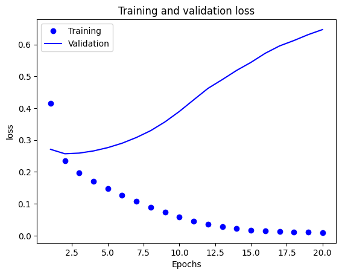

```
The loss stop decreasing at:  2 epochs
```

```python
# History plot of the loss for 20 epochs
plotHist(historyHOV20, 'loss', 'val_loss')
```

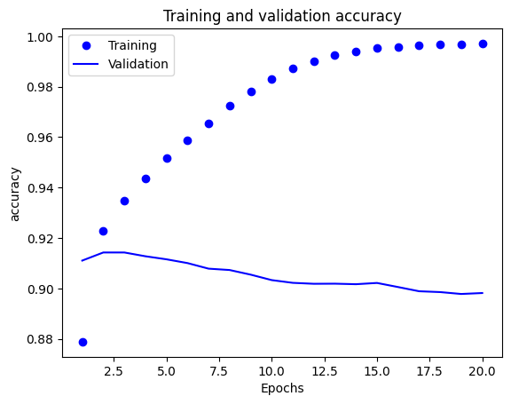

```
The accuracy stop increasing at:  2 epochs
```

```python
# History plot of the accuracy for 20 epochs
plotHist(historyHOV20, 'accuracy', 'val_accuracy')
```

```python
# # Plot a comparison chart
def plotComparisons(vals, labels,):
    import matplotlib.pyplot as plt

    x = ['loss', 'accuracy']
    loss = vals[0]
    accuracy = vals[1]
    x_axis = np.arange(len(loss))

    plt.subplots(figsize =(len(loss)*3 + 2,4))

    # Plot loss
    plt.subplot(1, 2, 1)
    plt.ylim(min(loss) - 0.02, max(loss) + 0.01)
    plt.bar(x_axis, loss, 0.4, label = labels, alpha=.8)
    plt.xticks(rotation=45)
    plt.xticks(x_axis, labels)
    plt.xlabel("Loss")
    plt.ylabel("Average percentage")

    # Plot accuracy
    plt.subplot(1, 2, 2)
    plt.ylim(min(accuracy) - 0.02, max(accuracy) + 0.01)
    plt.bar(x_axis, accuracy, 0.4, label = labels, alpha=.8)
    plt.xticks(rotation=45)
    plt.xticks(x_axis, labels)
    plt.xlabel("Accuracy")
    plt.ylabel("Average percentage")

    plt.show()
```

After training the model, I see that the validation accuracy is very similar between both models. However, the computational resources required by using K-Fold validation is larger than Simple Hold-out validation. Therefore for the rest of this analysis, only the Simple Hold-out validation will be used.

### Hyperparameter Tuning

After choosing a validation method and the optimal number of epochs, the next step is to tune the hyperparameters. The following are possible options to change:

- **Layers size**:
  - Current model has **3 layers 64/32/4**.

The 128/64/4 architecture produced the strongest balance of validation loss and validation accuracy, so it was selected for later experiments. Therefore, for the following tuning, the model will use the **128/64/4** layer.

- **Number of layers**
  - Current is number of layers is **3**: one input **ReLu** layer, one hidden **ReLu**, and one output **softmax** layer
  - When adding one more **ReLu** layer of size **64** (having 2 hidden layers), the loss grows larger and the accuracy grows smaller compared with the current model.
  - When reducing one layer of **ReLu** of size **64** (having only input and output layers), the accuracy grows even smaller than the model with 4 layers and the loss grows larger than the other two methods.

After the previous comparison, where the model with 3 layers **Relu/Relu/Softmax** and size **128/64/4** worked better than the other two options. Therefore, this model will be used to keep training the model.

- **Activation functions**
  - The current activation layers are the **ReLu/ReLu/Softmax** functions
  - The following is a comparison of the different combinations of the activation functions **ReLu**, **sigmoid** and **Tanh**. With **softmax** as the output layer.
    - “**Sigmoid** function is a special form of the logistic function. The output of this function is always between 0 and 1. It is denoted by $$σ(x) = \frac{1}{1+e^{-x}}$$ ” [Saeed].
    - **Tanh** is “the hyperbolic tangent function” [Brownlee]. The input and output values range between -1 and 1. It is denoted as $$σ(x) = \frac {e^{x}- e^{-x}}{e^{x}+ e^{-x}}$$

ReLU/ReLU/Softmax remained the best activation-function combination, so the architecture was kept unchanged

- **Loss functions**
  - The current loss function is **categorical_crossentropy** that is the best function for multiclass classification models.
  - For the second option, we compared the performance with **mean_squared_error**.

As we see in the results, the second option lowers the loss drastically but also lowers the accuracy. When trying to deeply understand the behavior of **MSE**, I found that “in classification MSE is not possible because the task is not convex, continuous or differentiable” [Washington.edu]. If the gradient finds a local minimum, it will stop. In order to have a reliable model, we continue using **categorical_crossentropy** for the rest of the training.

- **Optimizer functions**
  - The current optimizer function is the root mean square propagation **rmsprop**
  - The following are the comparison optimizer functions used:
    - “**Adam** stands for adaptive moment estimation, which is another way of using past gradients to calculate current gradients” [ Maithani]. It adapts the learning rate by using the square gradient and uses the momentum “moving average of the gradient” [Bushaev].
    - “**Nadam** is an acronym for Nesterov and Adam optimizer ”[Maithani]. It adapts the learning rate of each parameter by adding two gradient momentums.

### Retrain Training Model with All Training Data

After tuning the parameters and choosing the best functions, the next step is to retrain the model using the data in the training and validation datasets and evaluate its performance.

```python
# Extract data with train and valdation merged in one set
x_train, y_train, x_val, y_val, x_test, y_test = dataPreparation(train_data_merged,
                                                                 test_data_merged, 99)
```

```python
# Retrain the model by using 3 epochs, 3 layers

# Chosen hyperparameters
layersFinal = [128, 64, 4]
activationsFinal = ['relu', 'relu', 'softmax']
loss_f = 'categorical_crossentropy'
optzer_f = 'rmsprop'
metrics_f = 'accuracy'

tf.keras.backend.clear_session()
gc.collect()

# Train m_final with the choosen hyperparameters

# Iniciate Model
m_final  = iniModel(layersFinal, activationsFinal)
# Compile Model
m_final  = compileModel(m_final,
                         optimazer_func=optzer_f,
                         loss_func=loss_f,
                         metrics_func=metrics_f)
# Fit Model
m_final, hist_final = fitModel(m_final,
                               x_train,
                               y_train,
                               num_epochs=3)
```

### Evaluate Model with Test Data

The next step is to evaluate the trained model performance in unseen data.

```python
# Evaluate model
evaluationFinal = m_final.evaluate(x_test, y_test)
```

[output not shown]

```python
print('Loss scores')
print("\t Training data: \t", np.mean(hist_final.history['loss']))
print("\t Test data evaluation: \t", evaluationFinal[0])
print('Accuracy scores')
print("\t Training data: \t", np.mean(hist_final.history['accuracy']))
print("\t Test data evaluation: \t", evaluationFinal[1])
```

```
Loss scores
	 Training data: 	 0.2543178250392278
	 Test data evaluation: 	 0.29480481147766113
Accuracy scores
	 Training data: 	 0.9166329900423685
	 Test data evaluation: 	 0.9019736647605896
```

#### Predictions

Once the model has been evaluated, it can be used to predict the labels of the unseen data.

```python
# Make predictions on unseen data
y_pred = m_final.predict(x_test)
print("Softmax predictions sum by sample: \n", np.array(y_pred[:10]).sum(axis=1))
print("Predictions: \n", y_pred[:10])
print("Actual Labels: \n", y_test[:10])
```

```
238/238 ━━━━━━━━━━━━━━━━━━━━ 1s 4ms/step
Softmax predictions sum by sample:
 [0.99999994 1.         1.0000001  1.         1.         1.
 1.         1.0000001  0.99999994 1.        ]
Predictions:
 [[3.5788529e-02 6.6551074e-05 9.6297675e-01 1.1681487e-03]
 [1.0985930e-04 3.3413676e-07 1.0412191e-03 9.9884862e-01]
 [8.5500069e-03 2.6466589e-02 1.1839125e-02 9.5314437e-01]
 [4.7363937e-02 8.7110795e-02 1.7926857e-01 6.8625671e-01]
 [2.5899971e-01 6.9070621e-03 2.7559130e-02 7.0653415e-01]
 [2.1609283e-05 4.6632596e-08 1.5462950e-02 9.8451537e-01]
 [5.3491490e-06 6.9007418e-11 1.0306694e-05 9.9998432e-01]
 [3.6552321e-06 6.2650531e-07 6.1043925e-03 9.9389142e-01]
 [3.6652487e-02 8.5733726e-04 9.7699843e-02 8.6479026e-01]
 [1.2103521e-01 3.9514732e-03 7.2465861e-01 1.5035474e-01]]
Actual Labels:
 [[0. 0. 1. 0.]
 [0. 0. 0. 1.]
 [0. 0. 0. 1.]
 [0. 0. 0. 1.]
 [0. 0. 0. 1.]
 [0. 0. 0. 1.]
 [0. 0. 0. 1.]
 [0. 0. 0. 1.]
 [0. 0. 0. 1.]
 [0. 0. 0. 1.]]
```

```python
# Convert the predictions probabilities to one-hot encoding to compare with actual
import tensorflow
y_pred_OneHot = tensorflow.one_hot(tensorflow.argmax(y_pred, 1), depth=4)
y_pred_OneHot[:10]
```

```
<tf.Tensor: shape=(10, 4), dtype=float32, numpy=
array([[0., 0., 1., 0.],
       [0., 0., 0., 1.],
       [0., 0., 0., 1.],
       [0., 0., 0., 1.],
       [0., 0., 0., 1.],
       [0., 0., 0., 1.],
       [0., 0., 0., 1.],
       [0., 0., 0., 1.],
       [0., 0., 0., 1.],
       [0., 0., 1., 0.]], dtype=float32)>
```

#### Confusion Matrix

Creates a confusion matrix by using the predicted values and the actual values

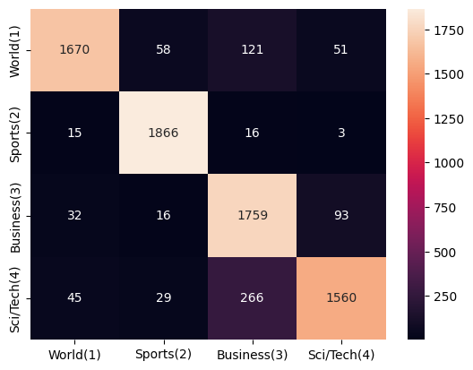

```python
# ------ https://hackernoon.com/multiclass-classification-with-keras -------
from sklearn.metrics import confusion_matrix, classification_report
import seaborn as sns
data_labels = ["World(1)", "Sports(2)", "Business(3)", 'Sci/Tech(4)' ]
confMatrix = confusion_matrix(np.argmax(y_test, 1), np.argmax(y_pred, 1))
sns.heatmap(confMatrix, annot=True, fmt='g', xticklabels=data_labels, yticklabels=data_labels)
```

From the confusion matrix we can extract the following information:

- The strongest class performance was observed for the Sports category, were only 3 predictions where mismatched with Sci/Tech class.
- The predictions have an overall accuracy of 90.197%

```python
truePos = np.trace(confMatrix)
overall_accuracy = truePos / len(y_pred) * 100

truePos = confMatrix[0][0] + confMatrix[1][1] + confMatrix[2][2] + confMatrix[3][3]
print("Correctly predicted: \t", truePos)
print("Number of predictions: \t", len(y_pred))
print("Overall accuracy: \t", overall_accuracy)
```

[output not shown]

#### Classification Report

Creates a classification report

```python
# ------ https://hackernoon.com/multiclass-classification-with-keras -------
print(classification_report(
   y_test,
   y_pred_OneHot,
   target_names=["World", "Sports", "Business", "Sci/Tech"]
   ))
```

[output not shown]

# Evaluation of the Project

## Model Preparation

During the model preparation, the dataset was chosen from Tensorflow libraries, however the data was not part of Keras library. This data was not prepared to be used directly for training a model. Therefore, some data processing was implemented. Initially the data processing was not part of the scope of the project, but I immediately understood the benefit of doing data processing before starting to train the model.

Data processing helped understand the structure and requirements of the input data of a model. Moreover, it shows how beneficial converting data into tensors of series or tensors of one-hot encoding facilitates the training of a model.

Another crucial step in preparing to train the model was to create functions that could be reused later. This became useful for implementing K-fold validation and for hyperparameter tuning. A vocabulary was needed to convert the data into series. To avoid information leakage when training a K-fold model it was necessary to create the vocabulary for each fold. Therefore the functions were used inside of the for loop. For the model training these functions were useful for parameter tuning because the functions were used inside for loops to try the different parameters.

One of the most important steps in preparation was to understand what was expected of the model:

- Understanding the data available: two string features of data merged into one and four classes of labels. S
- Finding the problem to solve by the model: one-label multiclass classification.
- Understanding the behavior and applications of different hyperparameters and functions that could be used in a multiclass classification problem. By understanding these steps in the preparation of the development of the model, the functionality and applications became more clear.

## Model Functionality

As demonstrated in this project, the model was based on classifying the data of news articles and their titles into one of four categories of news: World, Sports, Business, Sci/Tech. Classification is a problem that can be solved by using this multiclass classification model. There are other examples where this model could be beneficial:

- Classifying doctor notes into types of sickness.
- Separating reviews into different levels
- Classifying books into subjects
- Classifying emails into different categories
- Predicting animals or plants type based on images or information

# Project Improvement

## Limitations

The model achieved approximately 90% test accuracy; however, several limitations remain:

The model uses a simple feed-forward architecture rather than modern transformer-based approaches. Word order information is largely lost during vectorization. Hyperparameter tuning was limited by available computational resources. Results were evaluated on a single dataset and may not generalize to other news domains.

## Future Work

Potential improvements include:

Word embeddings LSTM networks GRU networks Transformer architectures Pre-trained language models such as BERT Automated hyperparameter optimization

# Conclusion

In conclusion, this project was based on using a preprocessed dataset that would help in the development of the model. However, a raw dataset was used to better understand the inputs needed for the model. This data set was preprocessed to fit the needs of the deep learning model by using tokenizations, sequencing, vectorization and encoding.

Once the data was ready, the planning of the model was started by understanding the problem to solve and how the model should be used. Then the data was used to train models that would be compared to choose the optimal option.

The next comparison was done by choosing different hyperparameters. The first step was comparing different layers and layer sizes. The best performance was with 3 layers where size 128/64/4 and the input and hidden layer was **Relu** activation function with an output **Softmax**. The loss function remained the same as categorical_crossentropy. And after comparing the optimizer functions the rmsprop was chosen as the best option for the model.

This project was based on understanding how to implement a deep learning model. While I use many combinations of hyperparameters and methods, I still need to learn more about other options available for instance, by applying different learning rates. However, I can now understand the functionality, the parts of a model, the validation and evaluation processes and the tuning of hyperparameters.

# References

## Works Cited

- “About Keras 3.” Keras, https://keras.io/about/. Accessed 16 February 2024.
- “AG News Dataset.” Papers With Code, https://paperswithcode.com/dataset/ag-news. Accessed 22 February 2024.
- “ag_news_subset.” TensorFlow, https://www.tensorflow.org/datasets/catalog/ag_news_subset. Accessed 16 February 2024.
- Bahrampour, Soheil, et al. “Comparative Study of Deep Learning Software Frameworks.” arXiv:1511.06435, 2015. arxiv.org, https://arxiv.org/. Accessed 16 02 2024.
- Brownlee, Jason. “A Gentle Introduction to the Rectified Linear Unit (ReLU) - MachineLearningMastery.com.” Machine Learning Mastery, 20 August 2020, https://machinelearningmastery.com/rectified-linear-activation-function-for-deep-learning-neural-networks/. Accessed 28 February 2024.
- Brownlee, Jason. “How to Choose an Activation Function for Deep Learning - MachineLearningMastery.com.” Machine Learning Mastery, 22 January 2021, https://machinelearningmastery.com/choose-an-activation-function-for-deep-learning/. Accessed 4 March 2024.
- Brownlee, Jason. “How to Choose Loss Functions When Training Deep Learning Neural Networks - MachineLearningMastery.com.” Machine Learning Mastery, 25 August 2020, https://machinelearningmastery.com/how-to-choose-loss-functions-when-training-deep-learning-neural-networks/. Accessed 28 February 2024.
- Brownlee, Jason. “What is a Confusion Matrix in Machine Learning - MachineLearningMastery.com.” Machine Learning Mastery, 15 August 2020, https://machinelearningmastery.com/confusion-matrix-machine-learning/. Accessed 23 February 2024.
- Bushaev, Vitaly. “Adam — latest trends in deep learning optimization. | by Vitaly Bushaev.” Towards Data Science, 22 October 2018, https://towardsdatascience.com/adam-latest-trends-in-deep-learning-optimization-6be9a291375c. Accessed 4 March 2024.
- Chollet, Francois. Deep Learning with Python. First ed., Manning, 2017. https://www.manning.com/, https://www.manning.com/books/deep-learning-with-python. Accessed 14 February 2024.
- “Classification: Precision and Recall | Machine Learning.” Google for Developers, 18 July 2022, https://developers.google.com/machine-learning/crash-course/classification/precision-and-recall. Accessed 23 February 2024.
- “How to Use Softmax Function for Multiclass Classification.” Turing, https://www.turing.com/kb/softmax-multiclass-neural-networks. Accessed 4 March 2024.
- Huang, Jason. “RMSProp.” Cornell University Computational Optimization Open Textbook, 21 December 2020, https://optimization.cbe.cornell.edu/index.php?title=RMSProp. Accessed 28 February 2024.
- Jain, Sandeep. “Confusion Matrix in Machine Learning.” GeeksforGeeks, 23 January 2024, https://www.geeksforgeeks.org/confusion-matrix-machine-learning/. Accessed 23 February 2024.
- Jain, Sandeep. “Introduction to Power Analysis in Python.” GeeksforGeeks, 26 March 2021, https://www.geeksforgeeks.org/introduction-to-power-analysis-in-python/. Accessed 27 February 2024.
- Maithani, Mohit. “Complete Guide to Tensorflow Keras Optimizers.” Analytics India Magazine, https://analyticsindiamag.com/guide-to-tensorflow-keras-optimizers/. Accessed 4 March 2024.
- “MIT Introduction to Deep Learning | 6.S191.” MIT 6.S191, MIT, 2023, https://www.youtube.com/watch?v=QDX-1M5Nj7s&list=WL&index=3. Accessed 15 February 2024.
- Pykes, Kurtis. “PyTorch vs TensorFlow vs Keras for Deep Learning: A Comparative Guide.” DataCamp, https://www.datacamp.com/tutorial/pytorch-vs-tensorflow-vs-keras. Accessed 16 February 2024.
- Saeed, Mehreen. “A Gentle Introduction To Sigmoid Function - MachineLearningMastery.com.” Machine Learning Mastery, 18 August 2021, https://machinelearningmastery.com/a-gentle-introduction-to-sigmoid-function/. Accessed 4 March 2024.
- “Softmax: The Activation Function That Drives Neural Networks.” Analytics Vidhya, https://www.analyticsvidhya.com/blog/2021/04/introduction-to-softmax-for-neural-network/. Accessed 4 March 2024.
- T, Kumaran. “Label Encoding vs. One Hot Encoding.” 20 03 2023, https://medium.com/@kumaran.t18/label-encoding-vs-a475f4bdbb60. Accessed 26 February 2024.
- “TensorFlow Core | Machine Learning for Beginners and Experts.” TensorFlow, https://www.tensorflow.org/overview. Accessed 16 February 2024.
- “TensorFlow Datasets: a collection of ready-to-use datasets.” TensorFlow, https://www.tensorflow.org/datasets. Accessed 16 February 2024.
- Washington.edu. “Chapter 6 Logistic Regression 6.1 MSE / Convexity.” Washington, https://courses.cs.washington.edu/courses/cse416/22su/lectures/6/lecture_6.pdf. Accessed 4 March 2024.
- “What is Deep Learning?” IBM, https://www.ibm.com/topics/deep-learning. Accessed 15 February 2024.

# Appendix

This appendix preserves additional outputs from the model-development process. These outputs are useful for academic traceability but were moved out of the main notebook flow to improve readability for portfolio and GitHub review.

## Appendix A: Validation Protocol Diagrams

**Figure 1. Simple Hold-Out Validation workflow.**

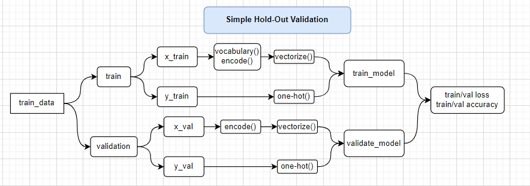

```python
## Validation Diagram Image

from IPython.display import Image
Image("pic 1.png")
```

**Figure 2. K-Fold Validation workflow.**  
K-folds separate into **K** parts where the validation set is taken from a different part and the training data is K-1 for every fold. At the end the scores from each fold are averaged

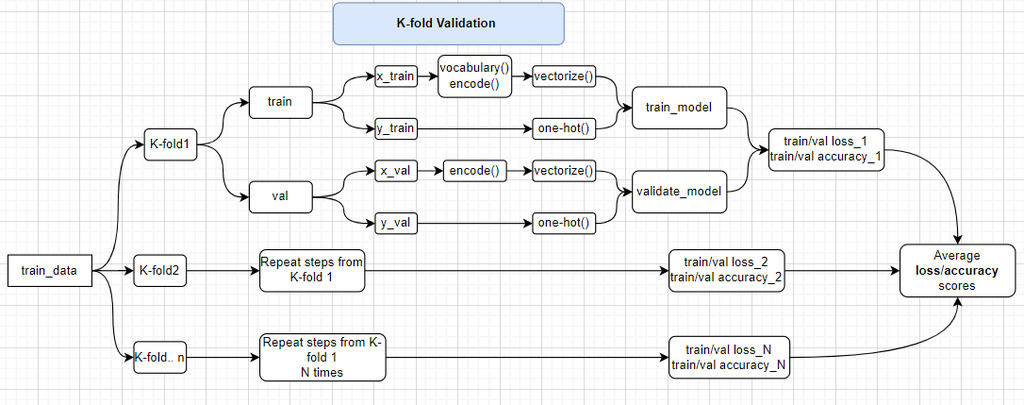

```python
from IPython.display import Image
Image("pic 2.png")
```

**Figure 3. Iterated K-Fold Validation workflow.**  
It follows the same procedure as K-fold validation, but it is repeated a number of iterations by shuffling the data on every iteration. At the end the scores from all the K-folds are averaged

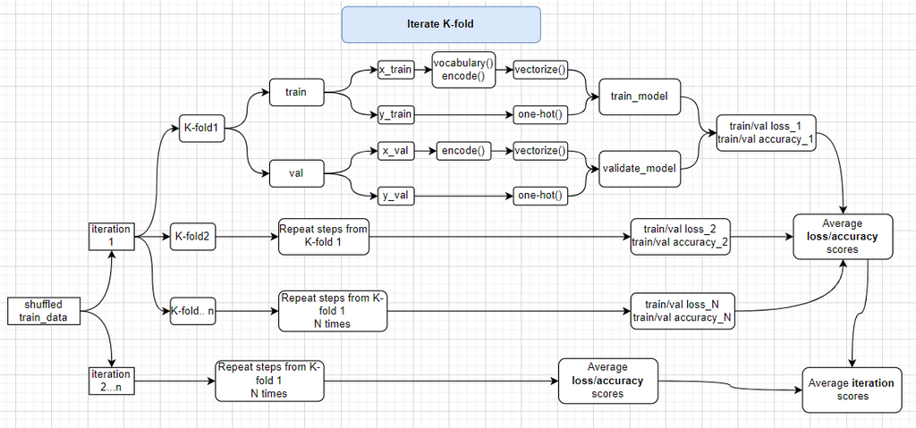

```python
from IPython.display import Image
Image("pic 3.png")
```

## Appendix B: Hyperparameter Tuning Details

### Model Regularization

The model can be improved by using different validation methods: K-fold validation and iteration K-fold validation. These methods can be used when the dataset is small or when accuracy is necessary. However, iteration k-fold validation used more space and memory than K-fold validation. Therefore, K-fold validation will be used to compare the accuracy with Simple Hold-out validation.

```python
# ----- https://livebook.manning.com/book/deep-learning-with-python/chapter-3/297 ------
# the main structure and logic of the code was from the book mentioned above.
# Some parts where replaced by functions

k = 5
num_val_samples = len(train_data_merged) // k
all_scores = []
all_val_loss = []
all_val_accuracy = []

for i in range(k):
    # clean up memory
    tf.keras.backend.clear_session()
    gc.collect()

    # Extract K-Fold data: prepares 20% validation data and 80% training data for each fold
    x_trainKFV, y_trainKFV, x_valKFV, y_valKFV, x_testKFV, y_testKFV = dataPreparationKFold(
        train_data_merged, test_data_merged, i, num_val_samples)

    # Hyperparameters KFV (same as modelHOV)
    layersKFV = [64, 32, 4]
    activationsKFV = ['relu', 'relu', 'softmax']

    # K-Fold Validation model
    # Train modelKFV with 5 epochs (I change to 5 epochs to be able to compare the performance)

    # Iniciate Model
    modelKFV = iniModel(layersKFV, activationsKFV)

    # Compile Model
    modelKFV = compileModel(modelKFV)

    # Fit Model
    modelKFV, historyKFV = fitModel(modelKFV,
                                    x_trainKFV, y_trainKFV,
                                    val_data=(x_valKFV, y_valKFV),
                                    num_epochs=5)
    all_val_loss.append(historyKFV.history['val_loss'])
    all_val_accuracy.append(historyKFV.history['val_accuracy'])
    # Evaluate the mean square error and the mean absolute error of the validation
    val_mse, val_mae = modelKFV.evaluate(x_valKFV, y_valKFV, verbose=0)
    all_scores.append(val_mae)

    # clean up memory
    del modelKFV, historyKFV
    del x_trainKFV, y_trainKFV, x_valKFV, y_valKFV, x_testKFV, y_testKFV
    tf.keras.backend.clear_session()
    gc.collect()
```

```python
val_lossKFV = np.mean([np.mean(fold_scores) for fold_scores in all_val_loss])
val_accKFV = np.mean([np.mean(fold_scores) for fold_scores in all_val_accuracy])
print('The validation loss for K-Fold Validation model is:')
print(val_lossKFV)
print('The validation accuracy for K-Fold Validation model is:')
print(val_accKFV)
```

[output not shown]

The following function plots the comparison between **Simple Hold-out** and **K-fold** validation models

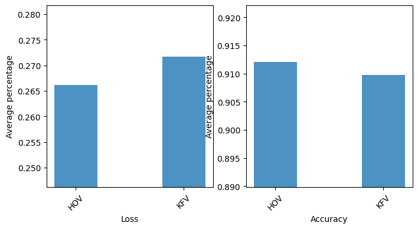

```python
# Comparison chart between Simple Hold-out and K-folds where k=5 and both with 5 epochs
plotComparisons([[val_lossHOV5, val_lossKFV], [val_accHOV5, val_accKFV]], ['HOV', 'KFV'])
```

### Layer-size comparison

```python
# Compare models by changing the number of layers using the optimal number of epochs 3

# Hyperparameters changing first and second layers
layers = [[64, 32, 4,],
          [64, 16, 4,],
          [64, 64, 4],
          [16, 32, 4],
          [32, 32, 4],
          [128, 32, 4],
          [32, 64, 4],
          [128, 64, 4]]
activationsHOV = ['relu', 'relu', 'softmax']
historiesLayers = []
for lyr_grp in layers:
    # clean up memory
    tf.keras.backend.clear_session()
    gc.collect()

    # Initialize model
    m3E  = iniModel(lyr_grp, activationsHOV)
    # Compile Model
    m3E  = compileModel(m3E )
    # Fit Model
    m3E, hist3E = fitModel(m3E, x_train, y_train, val_data=(x_val, y_val), num_epochs=3)
    historiesLayers.append(hist3E)
```

```python
layersNames = ["64/32/4", "64/16/4", "64/64/4", "16/32/4",
               "32/32/4", "128/32/4", "32/64/4", "128/64/4"]
# Calculate the mean loss and mean accuracy for each configuration.
scoresPerLayerSet = []
for val in historiesLayers:
    scoresPerLayerSet.append([
        np.mean(val.history['val_loss']),
        np.mean(val.history['val_accuracy'])])
```

```
[[0.2633490165074666, 0.9120000203450521],
 [0.2632681330045064, 0.9126805464426676],
 [0.26084183653195697, 0.9125694433848063],
 [0.2687993248303731, 0.9116111199061075],
 [0.2642718454202016, 0.9128611087799072],
 [0.26186975836753845, 0.9123611052831014],
 [0.26410093903541565, 0.9114166498184204],
 [0.2606873611609141, 0.9128750165303549]]
```

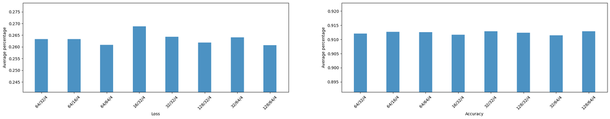

```python
# Plot the information above to be compared
plotComparisons([np.array(scoresPerLayerSet)[:,0], np.array(scoresPerLayerSet)[:,1]], layersNames)
```

```python
print("The layers that improve both the validation loss and accuracy are: ")
for i, scr in enumerate(scoresPerLayerSet):
    if scr[0] <= scoresPerLayerSet[0][0] and scr[1] >= scoresPerLayerSet[0][1]:
        print(layersNames[i], scr)
```

[output not shown]

```python
# Compare models by changing the number of layers using the optimal number of 3 epochs

# Hyperparameters changing first and second layers
layers = [[128, 64, 4], [128, 64, 64, 4], [128, 4]]
activationsHOV = [['relu', 'relu', 'softmax'], ['relu', 'relu', 'relu', 'softmax'], ['relu', 'softmax']]
histories_NLayers = []
for lyr_grp, act in zip(layers, activationsHOV):
    tf.keras.backend.clear_session()
    gc.collect()

    # Iniciate Model
    m_NLayers  = iniModel(lyr_grp, act)
    # Compile Model
    m_NLayers  = compileModel(m_NLayers )
    # Fit Model
    m_NLayers, hist_NLayers = fitModel(m_NLayers,
                                       x_train,
                                       y_train,
                                       val_data=(x_val, y_val),
                                       num_epochs=3)
    histories_NLayers.append(hist_NLayers)
```

```python
layersNames_NL = ["128/64/4_rrs", "128/64/64/4_rrrs", "128/4_rs"]
# Calculate the mean loss and mean accuracy for each configuration.
scoresPer_NL = []
for val in histories_NLayers:
    scoresPer_NL.append([np.mean(val.history['val_loss']), np.mean(val.history['val_accuracy'])])
```

```
[[0.2606873611609141, 0.9128750165303549],
 [0.2611132661501567, 0.9123472174008688],
 [0.27024582028388977, 0.9108611146608988]]
```

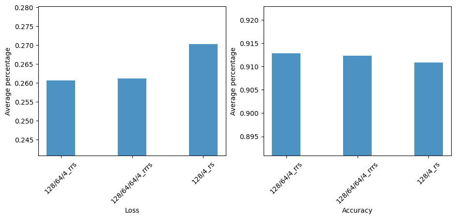

```python
# Plot the information above to be compared
plotComparisons([np.array(scoresPer_NL)[:,0], np.array(scoresPer_NL)[:,1]], layersNames_NL)
```

### Activation-function comparison

```python
# Compare models by changing the activation function using 3 epochs, 3 layers of 128/64/4

# Hyperparameters changing first and second layers
layers = [128, 64, 4]
activationsHOV = [['relu', 'relu', 'softmax'],
                  ['relu', 'sigmoid', 'softmax'],
                  ['relu', 'tanh', 'softmax'],
                  ['sigmoid', 'relu', 'softmax'],
                  ['tanh', 'relu', 'softmax'],
                  ['sigmoid', 'sigmoid', 'softmax'],
                  ['tanh', 'tanh', 'softmax']]
histories_DifLayers = []
for act in activationsHOV:
    tf.keras.backend.clear_session()
    gc.collect()

    # Train m_DifLayers with relu, sigmoid, tanh conbinations of layers

    # Iniciate Model
    m_DifLayers  = iniModel(layers, act)
    # Compile Model
    m_DifLayers  = compileModel(m_DifLayers )
    # Fit Model
    m_DifLayers, hist_DLayers = fitModel(m_DifLayers,
                                         x_train,
                                         y_train,
                                         val_data=(x_val, y_val),
                                         num_epochs=3)
    histories_DifLayers.append(hist_DLayers)
```

```python
layersNames_DL = ["relu/relu/softmax",
                  "relu/sigmoid/softmax",
                  "relu/tanh/softmax",
                  "sigmoid/relu/softmax",
                  "tanh/relu/softmax",
                  "sigmoid/sigmoid/softmax",
                  "tanh/tanh/softmax"]
# Calculate the mean loss and mean accuracy for each configuration.
scoresPer_DL = []
for val in histories_DifLayers:
    scoresPer_DL.append([np.mean(val.history['val_loss']), np.mean(val.history['val_accuracy'])])
```

```
[[0.2606873611609141, 0.9128750165303549],
 [0.2741767664750417, 0.9076388875643412],
 [0.2600802977879842, 0.9127777616182963],
 [0.33353208502133685, 0.8918472329775492],
 [0.2611449360847473, 0.9123611251513163],
 [0.43302709857622784, 0.8681944211324056],
 [0.2658786078294118, 0.9101249972979227]]
```

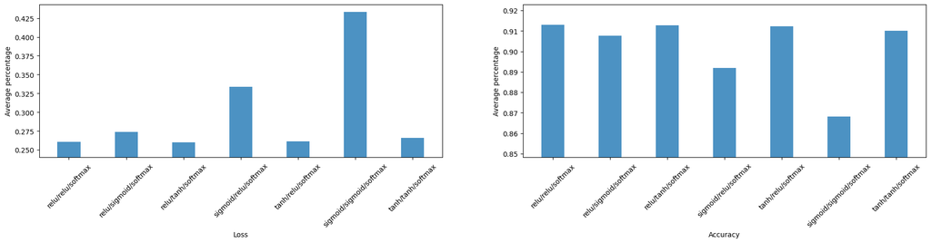

```python
# Plot the information above to be compared
plotComparisons([np.array(scoresPer_DL)[:,0], np.array(scoresPer_DL)[:,1]], layersNames_DL)
```

```python
print("The activation functions that improve both the validation loss and accuracy are: ")
for i, scr in enumerate(scoresPer_DL):
    if scr[0] <= scoresPer_DL[0][0] and scr[1] >= scoresPer_DL[0][1]:
        print(layersNames_DL[i], scr)
```

[output not shown]

### Loss Functions

```python
# Compare models by changing the loss function using 3 epochs, 3 layers(128_relu/64_relu/4_softmax)

# Hyperparameters changing loss function
layers = [128, 64, 4]
activationsHOV = ['relu', 'relu', 'softmax']
loss_funct = ['categorical_crossentropy',
              'mean_squared_error']
histories_DifLoss = []
for loss_f in loss_funct:
    tf.keras.backend.clear_session()
    gc.collect()

    # Train m_DifLoss with different loss functions

    # Iniciate Model
    m_DifLoss  = iniModel(layers, activationsHOV)
    # Compile Model
    m_DifLoss  = compileModel(m_DifLoss, loss_func = loss_f)
    # Fit Model
    m_DifLoss, hist_DLoss = fitModel(m_DifLoss,
                                     x_train,
                                     y_train,
                                     val_data=(x_val, y_val),
                                     num_epochs=3)
    histories_DifLoss.append(hist_DLoss)
```

```python
lossFuncNames = ['categorical_crossentropy',
                'mean_squared_error']
# Calculate the mean loss and mean accuracy for each configuration.
scoresPer_LossF = []
for val in histories_DifLoss:
    scoresPer_LossF.append([np.mean(val.history['val_loss']), np.mean(val.history['val_accuracy'])])
```

```
[[0.2606873611609141, 0.9128750165303549],
 [0.037424745659033455, 0.905055562655131]]
```

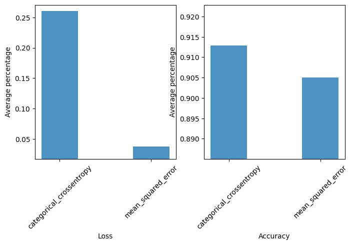

```python
# Plot the information above to be compared
plotComparisons([np.array(scoresPer_LossF)[:,0], np.array(scoresPer_LossF)[:,1]], lossFuncNames)
```

### Optimizer Functions

```python
# Compare models by changing the optimization function using 3 epochs, 3 layers

# Hyperparameters changing optimizer function
layers = [128, 64, 4]
activationsHOV = ['relu', 'relu', 'softmax']
optzer_funct = ['rmsprop', 'adam', 'nadam']
histories_DifOpt = []
for o_f in optzer_funct:
    tf.keras.backend.clear_session()
    gc.collect()
    # Train m_DifOpt with different optimizer functions

    # Iniciate Model
    m_DifOpt  = iniModel(layers, activationsHOV)
    # Compile Model
    m_DifOpt  = compileModel(m_DifOpt, optimazer_func = o_f)
    # Fit Model
    m_DifOpt, hist_DOpt = fitModel(m_DifOpt,
                                   x_train,
                                   y_train,
                                   val_data=(x_val, y_val),
                                   num_epochs=3)
    histories_DifOpt.append(hist_DOpt)
```

```python
optFuncNames = ['rmsprop', 'adam', 'nadam']
# Calculate the mean loss and mean accuracy for each configuration.
scoresPer_OptF = []
for val in histories_DifOpt:
    scoresPer_OptF.append([np.mean(val.history['val_loss']), np.mean(val.history['val_accuracy'])])
```

```
[[0.2606873611609141, 0.9128750165303549],
 [0.2737073103586833, 0.9101666808128357],
 [0.27114646633466083, 0.9115833242734274]]
```

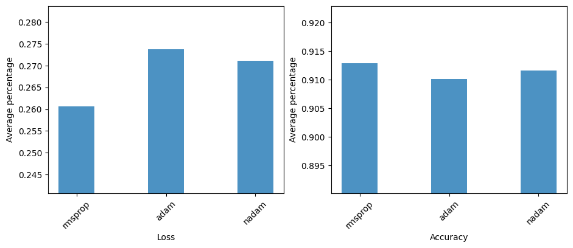

```python
# Plot the information above to be compared
plotComparisons([np.array(scoresPer_OptF)[:,0], np.array(scoresPer_OptF)[:,1]], optFuncNames)
```

```python
print("The optimization functions that improve both the validation loss and accuracy are: ")
for i, scr in enumerate(scoresPer_OptF):
    if scr[0] <= scoresPer_OptF[0][0] and scr[1] >= scoresPer_OptF[0][1]:
        print(optFuncNames[i], scr)
```

[output not shown]

## Appendix C: Sample Prediction Probabilities

### Predictions

```python
print("Softmax predictions sum by sample: \n", np.array(y_pred[:10]).sum(axis=1))
print("Predictions: \n", y_pred[:10])
print("Actual Labels: \n", y_test[:10])
```

[output not shown]